# Capstone Exercise Anderson

Sarah Anderson

Tuesday, April 28, 2015

## Capstone Exercise for the Software Carpentry Workshop

We will be using the Rmd files to create a short analysis report of the gapminder dataset.

The gapminder dataset includes data on GDP, life expectancy, and population for various years for each country worldwide.

```
##       country continent year lifeExp      pop gdpPercap
## 1 Afghanistan      Asia 1952  28.801  8425333  779.4453
## 2 Afghanistan      Asia 1957  30.332  9240934  820.8530
## 3 Afghanistan      Asia 1962  31.997 10267083  853.1007
## 4 Afghanistan      Asia 1967  34.020 11537966  836.1971
## 5 Afghanistan      Asia 1972  36.088 13079460  739.9811
## 6 Afghanistan      Asia 1977  38.438 14880372  786.1134
```

Three countries of interest are Brazil, Tanzania, and France. We are interested in how GDP has changed in each of these three countries overtime.

### Brazil

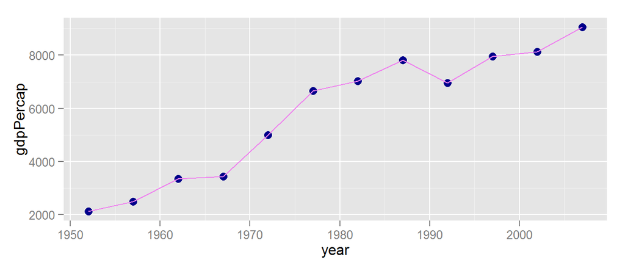

### Tanzania

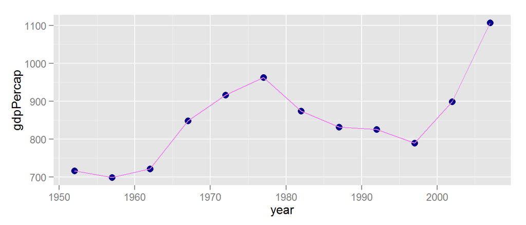

### France

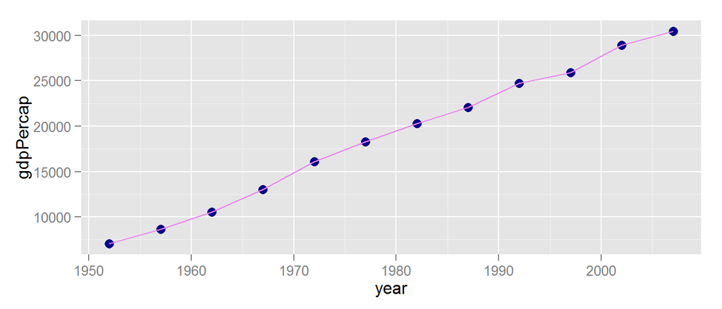

All three countries have experience growth over the last 60 years, but each of these countries have experience a different pattern. Brazil has experience periods of rapid growth with some periods of *slight decline but a consistent trend in growing GDP*. Tanzania experienced rapid growth in the 1960s and 1970s but then had a long period of *decline before exponential growth* starting around 2000. France has experienced *consistent linear growth* throughout the whole time period.

| continent | Mean | Minimum | Maximum |
| --- | --- | --- | --- |
| Africa | 48.86533 | 23.599 | 76.442 |
| Americas | 64.65874 | 37.579 | 80.653 |
| Asia | 60.06490 | 28.801 | 82.603 |
| Europe | 71.90369 | 43.585 | 81.757 |
| Oceania | 74.32621 | 69.120 | 81.235 |

Oceania and Europe are the regions with *highest* average life expectancy while Africa is the region with the *lowest* average life expectancy. Africa and Asia are regions with countries that have some of the *lowest* life expectancies while all regions have some countries with relatively *high* life expectancy. The following two histograms show a distribution of life expectancy.

Non-fixed Bin Width

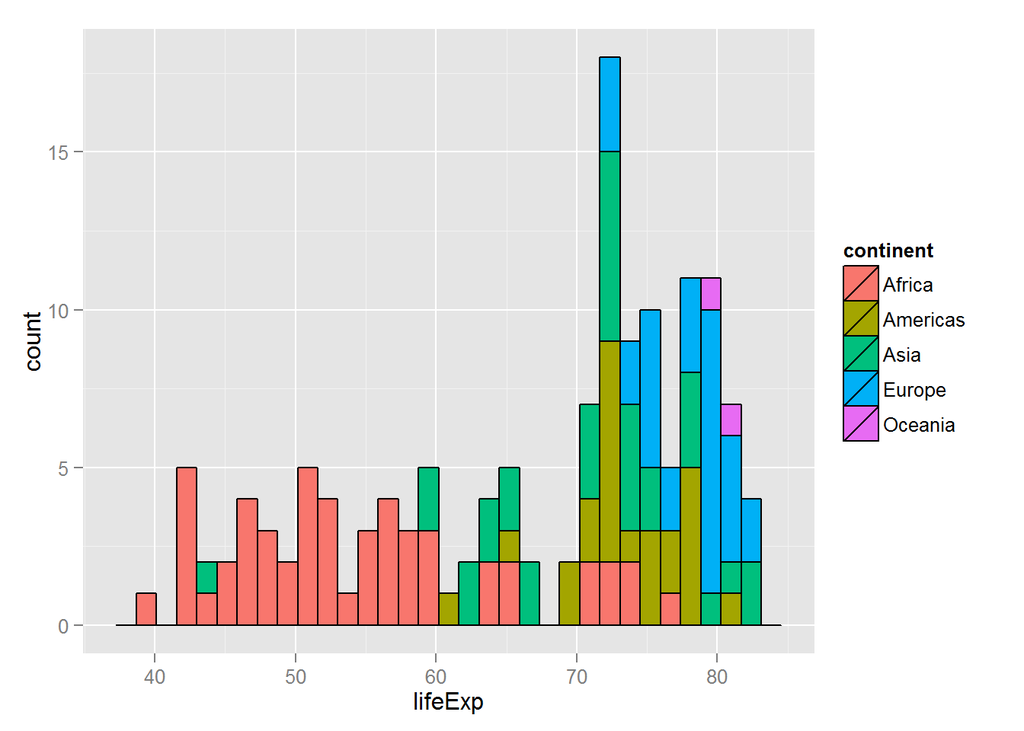

Fixed Bin Width

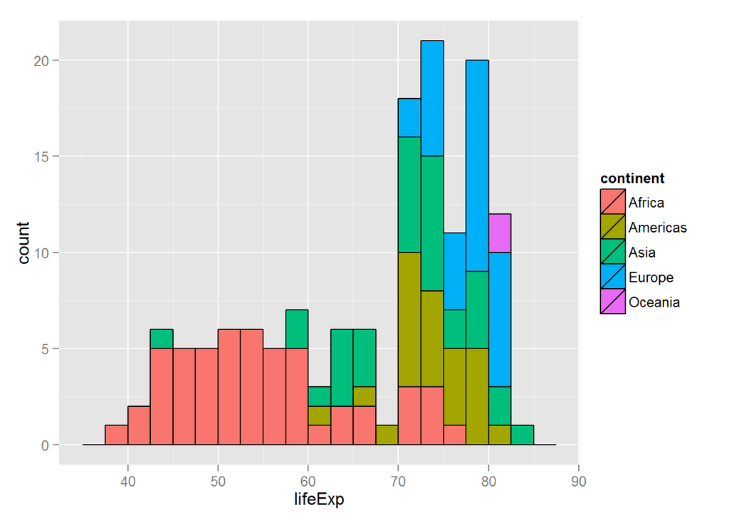

Binning lumps individual ages together to create larger groups. African countries predominately make up the lower range of life expectancies while Europe, Asia, and the Americans make up most of the bins containing higher life expectancies. Greater numbers of countries fall into the bins with life expectancies greater than 70 compared to bins with life exptectancies less than 70 years of age. Both binning methods illustrate the pattern, but the smaller bin widths (from the default) make it easier to pin point a medium value.